# Project Performance

Jessica Zhang

April 26, 2018

# Approach

- Irrelevant data could cause unnecessary noise and performance drop. So before analysis, we will need to remove irrelevant data.
- Null data needs to be dealt with as well.
- Naive analysis will be performed on the dataset as the baseline.
- Linear Regression model will be used for initial analysis.
- Random Forest and Expectation Maximization will also be used for analysis.

# Data cleaning

Columns 9-20 contains the campaign related information and are not related to clients’ profile. So we have removed the extra information and saved the new data to another file named “updatedbankingdata.csv.” In the rest of this project, we will be using data from updatedbankingdata.csv.

The updated data has totally 9 columns of data:

1. age (numeric)
2. job : type of job (categorical: “admin.”,“blue-collar”,“entrepreneur”,“housemaid”,“management”,“retired”,“self-employed”,“services”,“student”,“technician”,“unemployed”,“unknown”)
3. marital : marital status (categorical: “divorced”,“married”,“single”,“unknown”; note: “divorced” means divorced or widowed
4. education (categorical: “basic.4y”,“basic.6y”,“basic.9y”,“high.school”,“illiterate”,“professional.course”,“university.degree”,“unknown”)
5. default: has credit in default? (categorical: “no”,“yes”,“unknown”)
6. housing: has housing loan? (categorical: “no”,“yes”,“unknown”)
7. loan: has personal loan? (categorical: “no”,“yes”,“unknown”)
8. contact: contact communication type (categorical: “cellular”,“telephone”)
9. y: was the campaign successful? (“no”, “yes”)

# Naive Analysis – The Age Group Assumption

We assume the effectiveness of the campaign is somehow related to the age of the clients and we look at the number of success each age group generated in the past campaign, we can see the deposit distribution in the figure below:

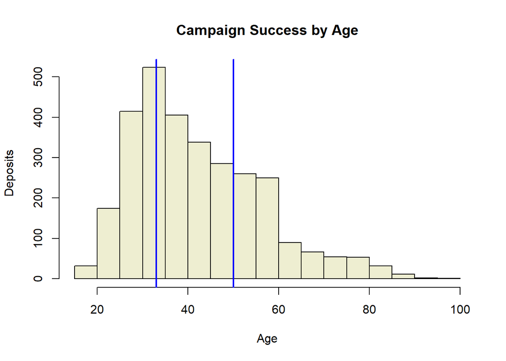

As we can see from the graph, the middle of the age group yields most deposits. A simple solution will be for the campaign team to focus on the middle 50 percentile of the client base and call the remaining later. The deposits will be generated during the busy season would be: 1336

The total number of deposites generated if half the clients were randomly called would be: 1495

This approach is less effective than the randomly picked clients. Therefore, this age group model is not a good model.